# Group Lab 2

Aldrin Carbonell, Johnny Nguyen, Justin Choi, Samuel Perng, Andy Tseng (Group 1)

February 5, 2019

# Mapping Origin-Destination Data on Employment and Industry in King County, Washington

However, it’s inevitable there will be issues and flaws with this type of data, and with census data in general. One glaring issue with census data is the sheer amount of people that must be accounted for. The term “microdata” is used when discussing census data, and it’s defined as statistics at the individual level. In December of 2018 (very recently!), the U.S. Census Bureau announced a proposal to stop making microdata widely available. This primarily concerns issues of privacy, though many argue that “data analysts aren’t disclosing individual responses to the public” (Government Executive, 2018). To increase privacy, statisticians must decrease accuracy (Cornell University, 2018). Another problem with census data has to do with interpolated values. In the field of Geographic Information Systems, interpolated values are utilized when maps are formatted into cells, grids or pixels; essentially “boxes” of data. These types of maps are known as **raster** maps. An example is shown below.

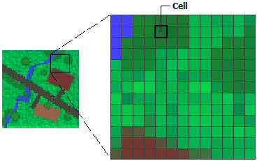

Interpolating values means that a single number is assigned to each cell. Basically, features in the same vicinity share the same characteristics. The main issue with this process is that multiple areas within the same cell may not share the same characteristics from its interpolated value. A more general problem has to do with census data collection by race. This mainly has to do with wording of questions on official Census surveys. The U.S. Census Bureau has blurred the definitions of certain ethnic groups, mainly Hispanics. A survey question has been incorporated regarding Hispanic origin, further complicating nonwhite Hispanic ethnicities. This may lead to the over-exaggeration of nonwhite ethnicities. Recently, the Justice Department has also proposed the addition of a citizenship question, which would likely deter many immigrant groups from responding on Census surveys (Washington Post, 2018).

### Area of Analysis and Main findings:

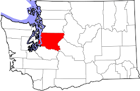

*Location of King County within Washington State*

For our data analysis, we focused on King County in Washington State. King County is the most populous county in Washington State, with the city of Seattle accounting for a majority of the population. This area was selected because of the potential to find interesting patterns within the LODES data. Seattle, Bellevue, and various other cities within King County have a plethora of job opportunities as well as a diverse range of people. One conclusion that can be made from the following data visualizations is that the highest number of jobs are situated near or within the city of Seattle, which is expected. Another less obvious finding is that the highest number of jobs in Census Tract Code 000200 (which will be discussed more in detail throughout the report) fall within the educational services sector, according to the Workplace Area Characteristics data. In terms of income, another finding was that the number of jobs that earn $1250 per month or less are mostly concentrated within or near Seattle. In the rest of this document, various visualizations will be shown utilizing the abundance of LODES data provided.

**Sources:**

https://www.govexec.com/management/2018/12/us-plans-stop-releasing-its-most-detailed-census-data/153400/

https://arxiv.org/abs/1808.06303

http://planet.botany.uwc.ac.za/nisl/GIS/spatial/chap_1_11.htm

https://www.washingtonpost.com/news/monkey-cage/wp/2018/02/06/theres-a-big-problem-with-how-the-census-measures-race/?noredirect=on&utm_term=.105bdcb70430

## OD, WAC, and RAC Bar Graphs

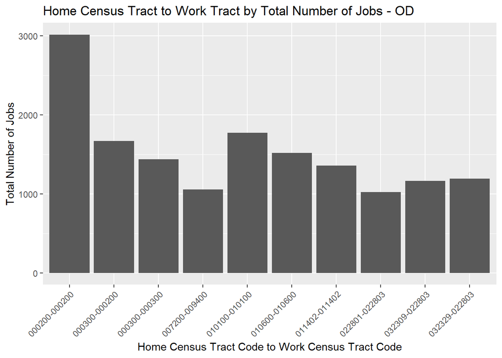

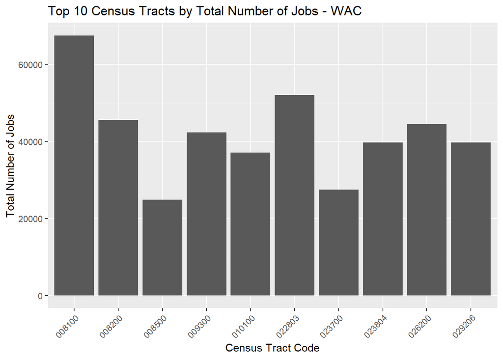

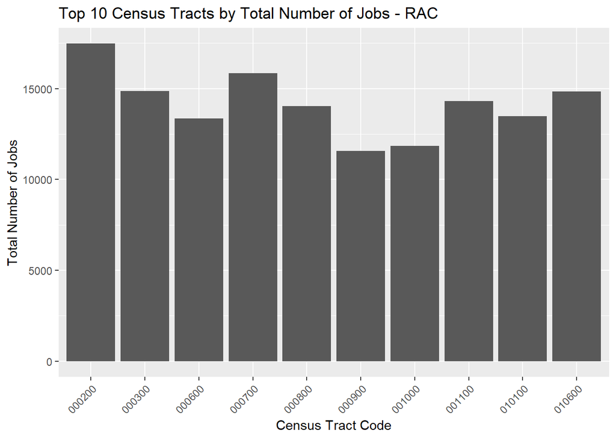

Looking at the first bar graph that represents the top Origin to Destination relationships, We saw that the area of Census Tract Code 000200 was a popular place to work. One thing that stuck out in the bar graph was a lot of people who live in 000200 also work in 000200. So we wanted to see what other home census tracts also travel to 000200.

## Aggregated Block and Tract Level Data for King County

For the two static maps below, we chose to visualize the number of jobs in each block and tract that require workers to have at least a Bachelor’s degree. In the LODES dataset, this variable is denoted as **CD04**.

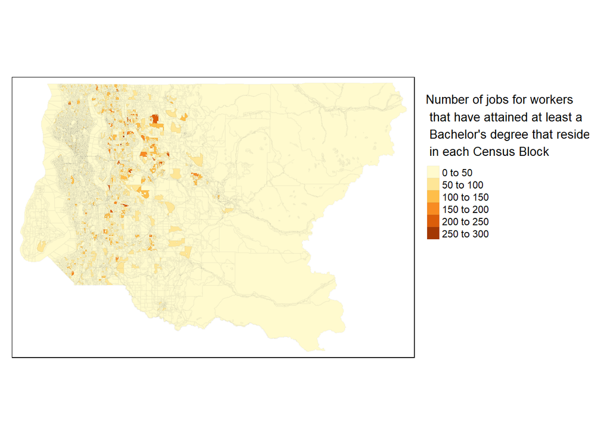

As you can see, the map above that represents block level data is far more disorganized than the the map below, which represents tract level data. Since King County is a large scale area relative to a single census block, the variable in this map is difficult to visualize at a full extent. This issue is fixed in the map below.

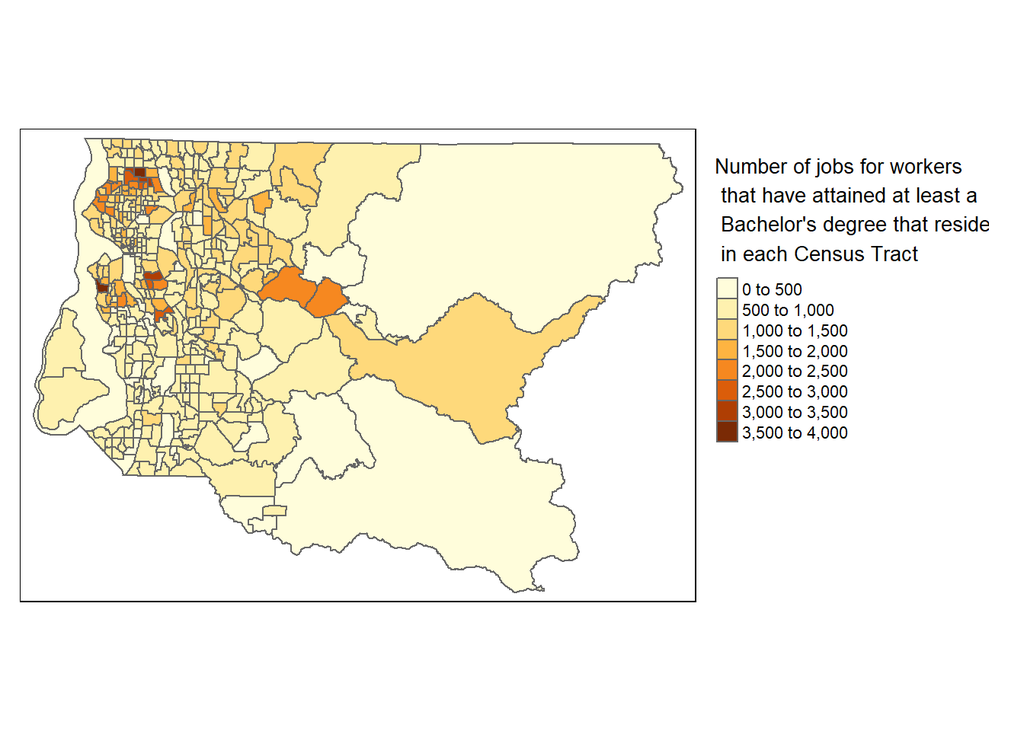

## Visualizing Origin-Destination Data

Below is a flow map visualization that represents the Origin to Destination relationship. These census tracts are the top 10 census tracts with the most number of jobs to 000200. Hovering over the lines will give you the number of jobs the Origin to Destination relationship has. Let’s see what this looks like on an actual map.

[interactive chart not shown]

Below is a Data frame with the row that has the information about tract 000200. Looking at the values in the WAC data set, we saw that CNS15 has the highest number. This column number represents the total number of jobs in the Education sector. So this tract has a lot of people commuting to this area for educational purposes.

```
##   wacData$wTract CNS01 CNS02 CNS03 CNS04 CNS05 CNS06 CNS07 CNS08 CNS09
## 2         000200   163     2     4  1645  1454   314  1836   707   478
##   CNS10 CNS11 CNS12 CNS13 CNS14 CNS15 CNS16 CNS17 CNS18 CNS19 CNS20
## 2   174   239   801    49   484  7922  1565   414  1935   353   779
##       GEOID10
## 2 53033000200
```

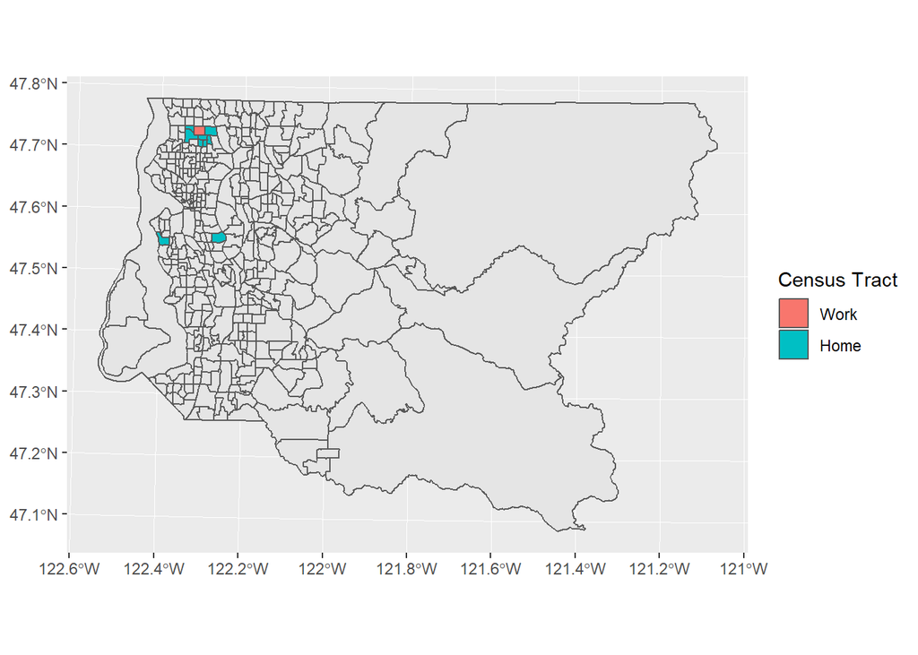

Here is the interactive map that represents the above visualization with respect to it’s location. From the visualization, the top census tracts that work here are all nearby this area, with the exception of the two places south of Seattle.

[interactive chart not shown]

## Calculating Moran’s I Statistic

One thing that I thought would be interesting to look at is which areas have the most Jobs in King County with earnings less than $1250/month or less. The data set that we looked at in this case was the WAC data set that represents the work characteristics of each census tract. Visualizing this data could help see which areas need a higher minimum wage!

CE01 Represents the Number of jobs with earnings $1250/month or less As we see here on the map below there seems to be a spatial correlation between Number of jobs earnings less than $1250/month. To see if there is a Spatial Correlation we calculated Moran’s I Statistic.

The Graph below plots the distribution of the Number of Jobs with earnings $1250/month or less across all of King County.

Since the Moran’s I Statistic is positive (indicated by the vertical bar) and the p-value is less than .05, we can assume that there is a spatial correlation for Number of jobs Earning Less than $1250/month.

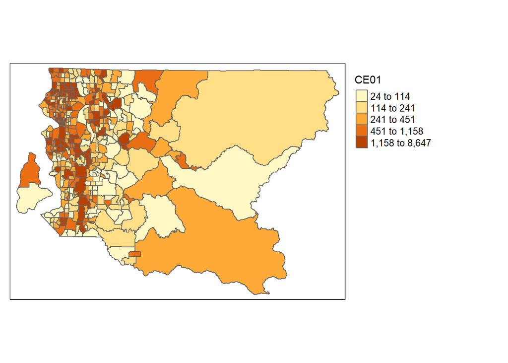

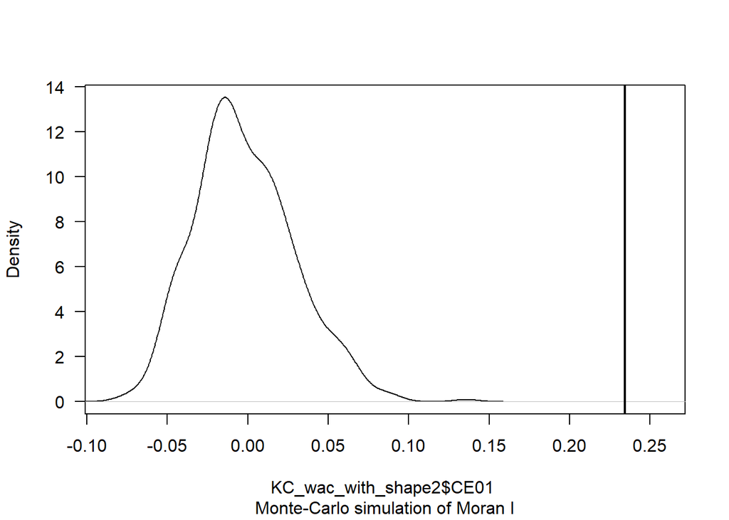

```
##
##  Monte-Carlo simulation of Moran I
##
## data:  KC_wac_with_shape2$CE01
## weights: lw
## number of simulations + 1: 600
##
## statistic = 0.23453, observed rank = 600, p-value = 0.001667
## alternative hypothesis: greater
```